# Análisis Descriptivo

José Rubén Niño Quevedo

2023-07-16

El siguiente informe tiene como objeto presentar algunas estadísticas descriptivas relacionadas con la data proporcionada para orientar la identificación de patrones y la propuesta de nuevas preguntas que orienten el análisis hacia el objetivo a cumplir.

```r
# Cargaremos las librerías que utilizaremos para este análisis
library(readr)
library(knitr)
library(kableExtra)
library(dplyr)
```

```r
library(ggplot2)
library(corrplot)
```

Inicialmente cargamos el archivo recibido para hacer una análisis exploratorio de la data existente.

```r
dataset_csv = read_csv("C:/Users/dell/Downloads/Prueba_Tecnica_R5/Data/dataset_original.csv")
```

# Resumen estadístico:

Para tener una visión general de los datos, determinaremos algunas estadísticas descriptivas para cada columna de la tabla inicial.

```r
names_col = names(dataset_csv)
names_col
```

```
##  [1] "num_documento_cliente"  "tipo_documento_cliente" "codigo_tienda"
##  [4] "total_compra"           "tipo_tienda"            "latitud_tienda"
##  [7] "longitud_tienda"        "id_barrio"              "nombre_barrio"
## [10] "fecha_compra"
```

```r
knitr::kable(head(dataset_csv, 10), caption = "**Primeros 10 registros del dataset dado**") %>%
  kable_styling(full_width = FALSE, font_size = 10) %>% row_spec(1:10, background = "lightblue")
```

**Primeros 10 registros del dataset dado**

| num_documento_cliente | tipo_documento_cliente | codigo_tienda | total_compra | tipo_tienda | latitud_tienda | longitud_tienda | id_barrio | nombre_barrio | fecha_compra |
| --- | --- | --- | --- | --- | --- | --- | --- | --- | --- |
| 6.861793e+18 | 1 | 14812028 | 22218042 | Tienda especializada | 3.402118 | -76.52568 | 737998244 | Canaverales Los Samanes | 2022-06-15 15:49:11 |
| 1.552970e+18 | 1 | 14388938 | 21583407 | Tienda especializada | 3.468765 | -76.48494 | 737998896 | Jorge Eliecer Gaitan | 2022-10-02 22:14:54 |
| -4.075905e+18 | 1 | 12370698 | 6185349 | Tienda especializada | 3.400743 | -76.52484 | 737998244 | Canaverales Los Samanes | 2022-01-10 0:27:57 |
| 3.539340e+18 | 1 | 10313583 | 10313583 | Tienda especializada | 3.369544 | -76.52366 | 738000400 | Lili | 2022-09-02 16:30:24 |
| 5.595555e+18 | 1 | 14358071 | 28716142 | Tienda especializada | 3.419046 | -76.49773 | 737996734 | El Poblado | 2022-03-20 2:56:49 |
| -1.611987e+18 | 1 | 12152989 | 6076495 | Tienda especializada | 3.371119 | -76.52774 | 738000407 | Urbanización San Juaquín | 2022-04-30 2:24:32 |
| -7.020300e+18 | 1 | 11576899 | 5788450 | Tienda especializada | 3.366646 | -76.53709 | 738000383 | Urbanización Ciudad Jardín | 2022-08-21 8:42:03 |
| -1.095912e+17 | 1 | 11863172 | 5931586 | Tienda especializada | 3.413940 | -76.51942 | 737997089 | Villa del Sur | 2022-10-16 10:53:15 |
| -4.154111e+17 | 1 | 11272457 | 5636229 | Tienda especializada | 3.475004 | -76.52895 | 737998252 | Chipichape | 2022-05-19 4:05:22 |
| -6.835724e+18 | 1 | 10005445 | 5002723 | Tienda especializada | 3.470987 | -76.52067 | 737998812 | Prados del Norte | 2022-05-25 0:22:51 |

```r
summary(dataset_csv)
```

```
##  num_documento_cliente tipo_documento_cliente codigo_tienda
##  Min.   :-9.219e+18    Min.   :1.000          Min.   :6.000e+01
##  1st Qu.:-4.636e+18    1st Qu.:1.000          1st Qu.:2.683e+03
##  Median :-5.789e+16    Median :1.000          Median :6.605e+03
##  Mean   : 5.405e+16    Mean   :1.029          Mean   :1.022e+08
##  3rd Qu.: 4.578e+18    3rd Qu.:1.000          3rd Qu.:1.329e+07
##  Max.   : 9.223e+18    Max.   :9.000          Max.   :2.100e+09
##   total_compra       tipo_tienda        latitud_tienda  longitud_tienda
##  Min.   :3.000e+01   Length:94610       Min.   :3.333   Min.   :-76.56
##  1st Qu.:2.568e+03   Class :character   1st Qu.:3.402   1st Qu.:-76.54
##  Median :2.043e+04   Mode  :character   Median :3.437   Median :-76.53
##  Mean   :1.642e+08                      Mean   :3.432   Mean   :-76.53
##  3rd Qu.:7.370e+06                      3rd Qu.:3.464   3rd Qu.:-76.52
##  Max.   :1.232e+11                      Max.   :3.499   Max.   :-76.46
##    id_barrio         nombre_barrio      fecha_compra
##  Min.   :737995769   Length:94610       Length:94610
##  1st Qu.:737998194   Class :character   Class :character
##  Median :737998832   Mode  :character   Mode  :character
##  Mean   :737999560
##  3rd Qu.:737999427
##  Max.   :738068452
```

Se observa que:

- Trabajaremos con una matriz de tamaño $94610 \times 10$.
- Tres (3) de sus columnas son del tipo varchar: tipo_tienda, nombre_barrio, fecha_compra.
- Aunque las demás son del tipo double, tipo_documento_cliente, codigo_tienda, id_barrio son variables para las cuales no tedría sentido calcular las medidas de tendencia central (MTC).
- Algunos valores de la variable num_documento_cliente son negativos, lo que se motivaría el hacer una limpieza de la data antes de hacer cualquier análisis. Además, los registros no están ordenados. Para los análisis posteriores se partirá de un dataset ordenado por fecha de compra y sin valores negativos en num_documento_cliente.

```r
csv_ord = dataset_csv %>% arrange(fecha_compra)
csv_ord$num_documento_cliente = abs(csv_ord$num_documento_cliente)

knitr::kable(head(csv_ord, 10), caption = "**Primeros 10 registros del dataset ordenado**") %>% kable_styling(full_width = FALSE, font_size = 10) %>% row_spec(1:10, background = "lightgreen")
```

**Primeros 10 registros del dataset ordenado**

| num_documento_cliente | tipo_documento_cliente | codigo_tienda | total_compra | tipo_tienda | latitud_tienda | longitud_tienda | id_barrio | nombre_barrio | fecha_compra |
| --- | --- | --- | --- | --- | --- | --- | --- | --- | --- |
| 3.311323e+18 | 1 | 10327682 | 5163841.0 | Tienda especializada | 3.472221 | -76.52659 | 737998194 | Santa Mónica Residencial | 2022-01-01 0:00:31 |
| 3.770728e+18 | 1 | 13443601 | 6721800.5 | Tienda especializada | 3.418480 | -76.53572 | 737998098 | Departamental | 2022-01-01 0:11:59 |
| 3.369988e+18 | 1 | 829 | 414.5 | Tienda Outlet | 3.373327 | -76.54071 | 738000377 | Unicentro Cali | 2022-01-01 0:18:11 |
| 3.354386e+18 | 1 | 1622720205 | 1622720205.0 | Tienda Regional | 3.404655 | -76.53373 | 737998934 | Primero de Mayo | 2022-01-01 0:18:49 |
| 2.461998e+18 | 1 | 620 | 5890.0 | Supermercado | 3.453735 | -76.52511 | 737998935 | San Nicolás | 2022-01-01 0:28:16 |
| 3.515069e+18 | 1 | 1104423595 | 1104423595.0 | Tienda Regional | 3.435008 | -76.53861 | 737998087 | El Cedro | 2022-01-01 0:30:51 |
| 4.671438e+18 | 1 | 5787 | 2893.5 | Supermercado | 3.487545 | -76.49945 | 737998826 | Los Guaduales | 2022-01-01 0:53:22 |
| 1.764897e+18 | 1 | 14474746 | 7237373.0 | Tienda especializada | 3.392659 | -76.53257 | 737998941 | La Hacienda | 2022-01-01 10:02:35 |
| 3.224565e+18 | 1 | 741 | 1111.5 | Tienda Outlet | 3.488660 | -76.49363 | 737998878 | Los Alcázares | 2022-01-01 10:03:53 |
| 2.659787e+18 | 1 | 1076121198 | 4304484792.0 | Tienda Regional | 3.366660 | -76.52123 | 738000400 | Lili | 2022-01-01 10:10:44 |

```r
write.csv(csv_ord, file ="C:/Users/dell/Downloads/Prueba_Tecnica_R5/Data/dataset.csv", row.names = TRUE) #Este archivo es el que se utilizará para dar respuesta a las preguntas de la pueba.
```

Observando las correlaciones se puede infereir que la tienda está relacionada en el total de compras por parte de los clientes.

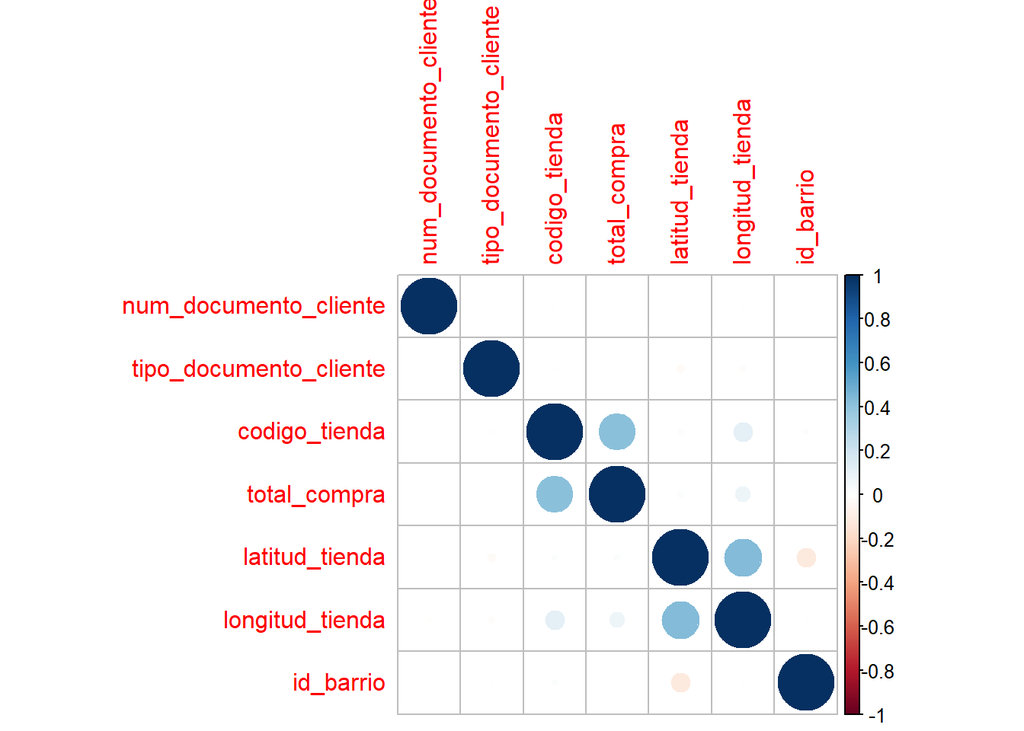

```r
chosen_col_0 <- c("num_documento_cliente", "tipo_documento_cliente", "codigo_tienda", "total_compra", "latitud_tienda", "longitud_tienda", "id_barrio")

Corr_AB = cor(csv_ord[, chosen_col_0])
corrplot(cor(csv_ord[, chosen_col_0]))
```

## Analisis exploratorio de datos sobre clientes

El número total de clientes diferentes es:

```r
num_clientes <- length(unique(csv_ord$num_documento_cliente))
num_clientes
```

```
## [1] 10000
```

El mín y el máx de la variable tipo_documento_cliente indica que podríamos llegar a tener hasta 9 tipos de documentos diferentes.

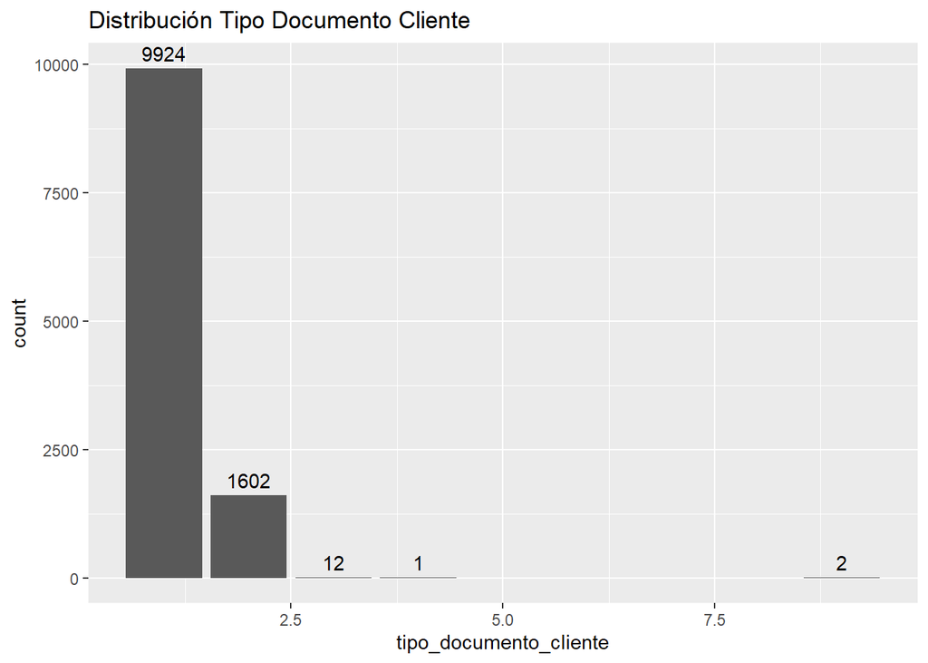

```r
chosen_col_1 <- c("num_documento_cliente", "tipo_documento_cliente")
subset_1 = unique(csv_ord[, chosen_col_1])

ggplot(subset_1, aes(x = tipo_documento_cliente)) + geom_bar(show.legend = TRUE) + geom_text(stat = 'count', aes(label = after_stat(count)), vjust = -0.5) + labs(title = "Distribución Tipo Documento Cliente")
```

**Observación:** Tenemos 10000 clientes diferentes, pero en la gráfica se observan más y distribuidos en cinco (5) categorías: 1, 2, 3, 4 y 9. En la categoría 1 hay 9924 clientes. Lo anterior indica que debemos identificar los clientes que fueron clasificados en más de una categoría. La siguiente tabla presenta a aquellos clientes que tienen más de un tipo de documento:

```r
# Paso 1: Agrupar los datos por "num_documento_cliente"
grupos = subset_1 %>% group_by(num_documento_cliente) %>%
# Paso 2: Contar la cantidad de "tipo_documento_cliente" distintos
  summarize(num_tipos_documento = n_distinct(tipo_documento_cliente))
# Paso 3: Filtrar aquellos casos con más de un "tipo_documento_cliente"
num_documentos_multiples_tipos = grupos %>% filter(num_tipos_documento > 1)
num_documentos_multiples_tipos
```

```
## # A tibble: 1,541 × 2
##    num_documento_cliente num_tipos_documento
##                    <dbl>               <int>
##  1               3.76e16                   2
##  2               3.92e16                   2
##  3               5.57e16                   2
##  4               5.77e16                   2
##  5               6.58e16                   2
##  6               6.67e16                   2
##  7               7.05e16                   2
##  8               7.32e16                   2
##  9               7.58e16                   2
## 10               8.11e16                   2
## # ℹ 1,531 more rows
```

Una vez identificados los clientes únicos, se presenta la clasificación inicial de los mismos:

```r
data_1A <- subset_1 %>% group_by(num_documento_cliente) %>% mutate(contador = row_number())
data_1A <- data_1A %>% filter(contador < 2)
data_1A = subset(data_1A, select = -contador)
print(data_1A)
```

```
## # A tibble: 10,000 × 2
## # Groups:   num_documento_cliente [10,000]
##    num_documento_cliente tipo_documento_cliente
##                    <dbl>                  <dbl>
##  1               3.31e18                      1
##  2               3.77e18                      1
##  3               3.37e18                      1
##  4               3.35e18                      1
##  5               2.46e18                      1
##  6               3.52e18                      1
##  7               4.67e18                      1
##  8               1.76e18                      1
##  9               3.22e18                      1
## 10               2.66e18                      1
## # ℹ 9,990 more rows
```

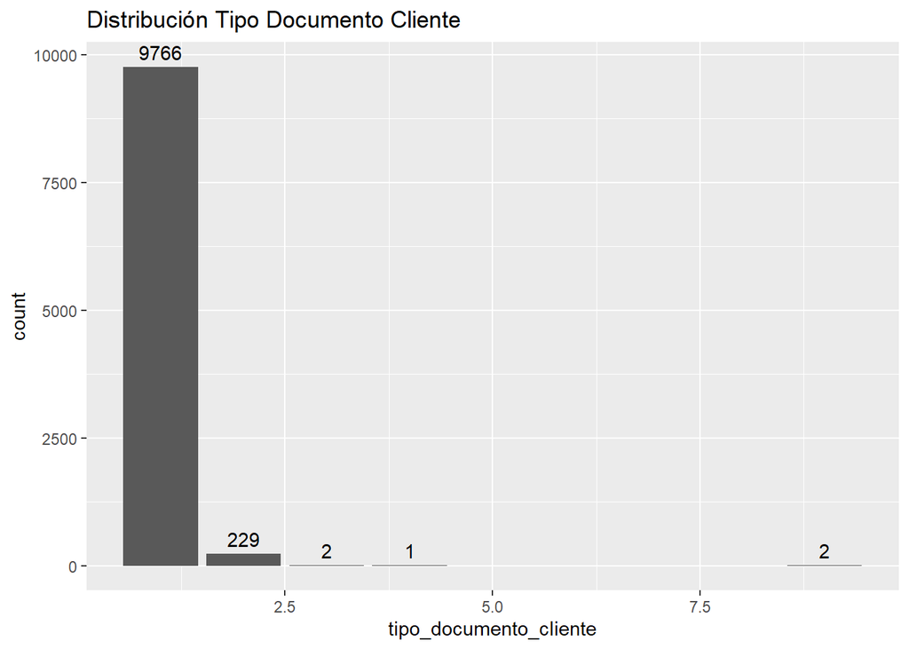

```r
ggplot(data_1A, aes(x = tipo_documento_cliente)) + geom_bar(show.legend = TRUE) + geom_text(stat = 'count', aes(label = after_stat(count)), vjust = -0.5) + labs(title = "Distribución Tipo Documento Cliente")
```

## Analisis exploratorio de datos sobre tiendas

El número total de tiendas es:

```r
num_tiendas = length(unique(csv_ord$codigo_tienda))
num_tiendas
```

```
## [1] 6014
```

Dichas tiendas están clasificadas en los siguientes categorías:

```r
chosen_col_2 = c("codigo_tienda", "tipo_tienda")
subset_2 = unique(csv_ord[, chosen_col_2])

data_1B = subset_2 %>% group_by(tipo_tienda) %>% count(tipo_tienda)
# Calculo de los valores porcentuales
total <- sum(data_1B$n)
data_1B$porcentaje <- (data_1B$n / total) * 100

data_1B
```

```
## # A tibble: 6 × 3
## # Groups:   tipo_tienda [6]
##   tipo_tienda              n porcentaje
##   <chr>                <int>      <dbl>
## 1 Hipermercado            19      0.316
## 2 Minimercado              7      0.116
## 3 Supermercado           226      3.76
## 4 Tienda Outlet           40      0.665
## 5 Tienda Regional        336      5.59
## 6 Tienda especializada  5388     89.6
```

Hay 6014 tiendas diferentes, distribuidos en seis (6) categorías: Tienda especializada, Tienda Outlet, Supermercado, Hipermercado, Minimercado, Tienda Regional. Hay 5388 tiendas especializadas y 336 tiendas regionales. Graficamente:

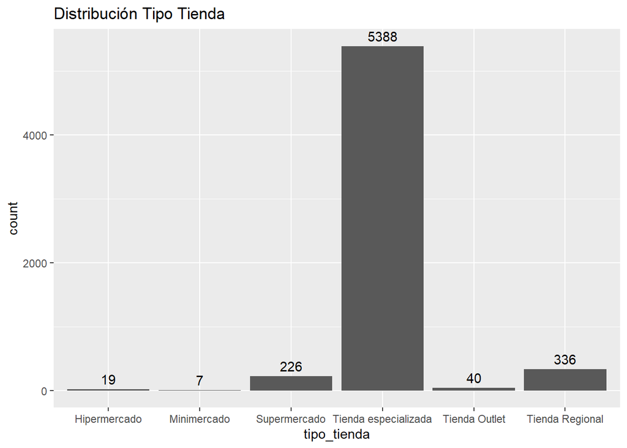

```r
# Gráfico de barras número de tiendas por tipo
ggplot(subset_2, aes(x = tipo_tienda)) + geom_bar(show.legend = TRUE) + geom_text(stat = 'count', aes(label = after_stat(count)), vjust = -0.5) + labs(title = "Distribución Tipo Tienda")
```

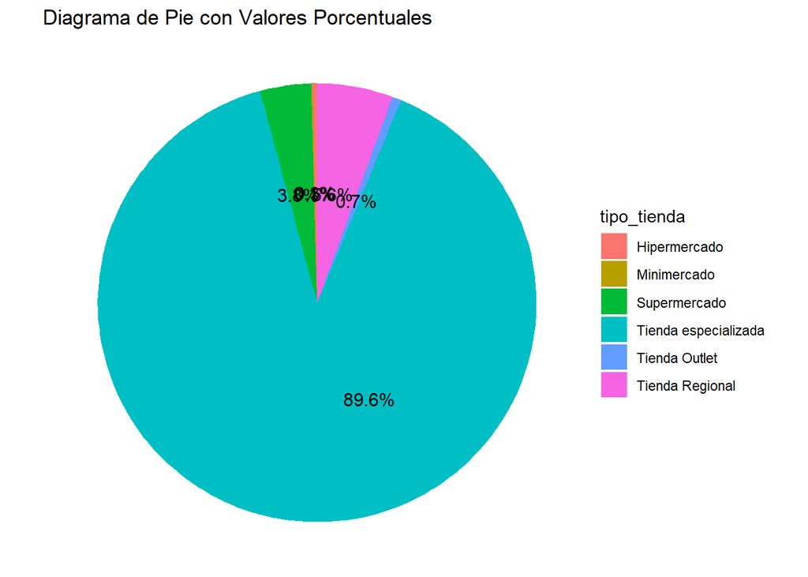

```r
# Gráfico de pie con los valores porcentuales
ggplot(data_1B, aes(x = "", y = porcentaje, fill = tipo_tienda)) +
  geom_bar(stat = "identity", width = 1) + coord_polar(theta = "y") +
  geom_text(aes(label = paste0(round(porcentaje, 1), "%")), position = position_stack(vjust = 0.4), size = 4) +
  theme_void() +
  labs(title = "Diagrama de Pie con Valores Porcentuales")
```

Por ota parte, los mín y máx en las variables latitud_tienda y longitud_tienda podrían ser utilizados para determinar una región donde se podría georreferenciar las tiendas.Podemos visualizar la cobertura a través de un gráfico de dispersión como el que se observa a continuación:

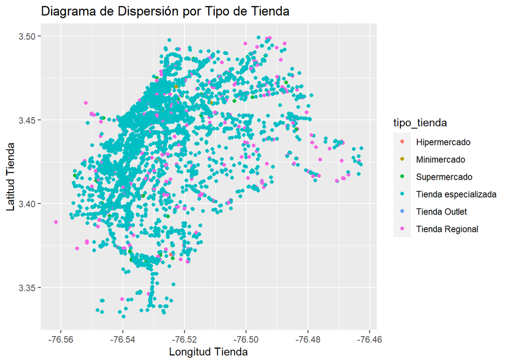

```r
chosen_col_3 <- c("latitud_tienda", "longitud_tienda", "tipo_tienda")
subset_3 = unique(csv_ord[, chosen_col_3])

ggplot(data = subset_3, aes(x = longitud_tienda, y = latitud_tienda, color = tipo_tienda)) +
  geom_point() +
  labs(x = "Longitud Tienda", y = "Latitud Tienda", title = "Diagrama de Dispersión por Tipo de Tienda")
```

Se puede observar que hay una gran cantidad de tiendas especializadas concentradas entre las latitudes 3.45 y 3.47 y entre la longitudes -76.54 y -76.52. También se observa que las tiendas regionales hacen una “buena cobertura”.

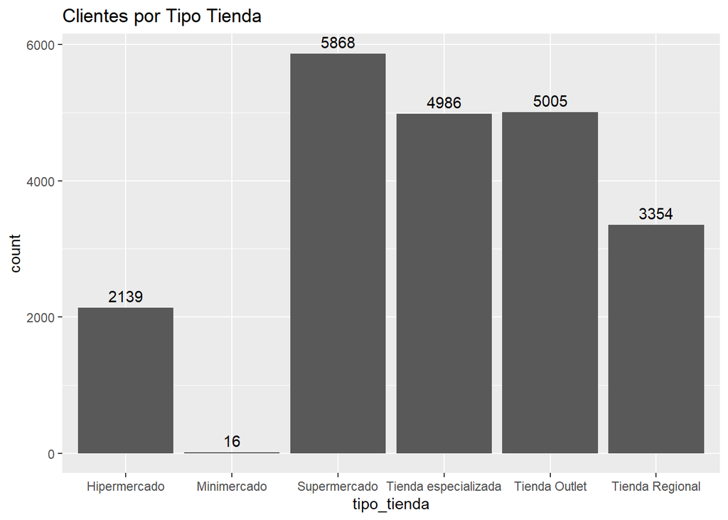

```r
chosen_col_4 <- c("num_documento_cliente", "tipo_tienda")
subset_4 = unique(csv_ord[, chosen_col_4])

ggplot(subset_4, aes(x = tipo_tienda)) + geom_bar(show.legend = TRUE) + geom_text(stat = 'count', aes(label = after_stat(count)), vjust = -0.5) + labs(title = "Clientes por Tipo Tienda")
```

A partir del número total de clientes y de la gráfica se puede afirmar que existen clientes que hacen compras en diferentes tipos de tiendas.

```r
# Paso 1: Agrupar los datos por "num_documento_cliente"
grupos = subset_4 %>% group_by(num_documento_cliente) %>%
# Paso 2: Contar la cantidad de "tipo_tienda" distintos
  summarize(num_tipos_tienda = n_distinct(tipo_tienda))
# Paso 3: Filtrar aquellos casos con más de un "tipo_tienda"
num_documentos_multiples_tipos2 = grupos %>% filter(num_tipos_tienda > 0)

data_1C = num_documentos_multiples_tipos2 %>% group_by(num_tipos_tienda) %>% count(num_tipos_tienda)
total <- sum(data_1B$n)
data_1C$porcentaje <- (data_1C$n / total) * 100

data_1C
```

```
## # A tibble: 6 × 3
## # Groups:   num_tipos_tienda [6]
##   num_tipos_tienda     n porcentaje
##              <int> <int>      <dbl>
## 1                1  4696    78.1
## 2                2  1892    31.4
## 3                3  1470    24.4
## 4                4  1235    20.5
## 5                5   704    11.7
## 6                6     3     0.0499
```

Lo anterior indica que más de la mitad de los clientes hacen compras en más de un tipo de tienda.

Las tiendas están distribuidas en 277 barrios.

```r
num_barrios = length(unique(csv_ord$id_barrio))
num_barrios
```

```
## [1] 277
```

La presencia del tipo de tienda en los barrios es:

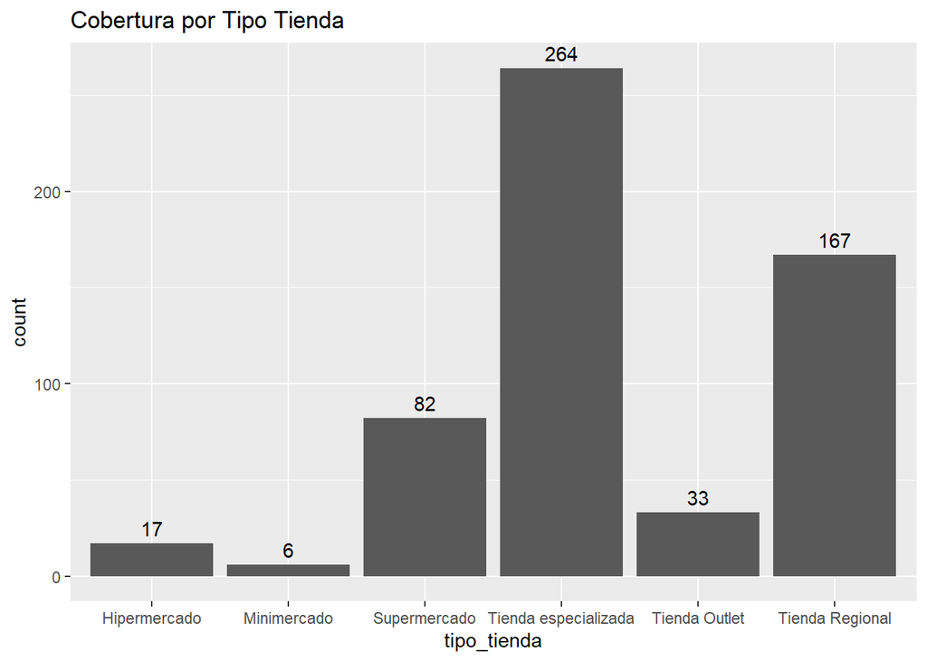

```r
chosen_col_5 <- c("id_barrio", "tipo_tienda")
subset_5 = unique(csv_ord[, chosen_col_5])

ggplot(subset_5, aes(x = tipo_tienda)) + geom_bar(show.legend = TRUE) + geom_text(stat = 'count', aes(label = after_stat(count)), vjust = -0.5) + labs(title = "Cobertura por Tipo Tienda")
```

## Analisis exploratorio de datos sobre fechas

```r
#Análisis temporal:
#Para extraer el año, mes o día de la semana de la columna "fecha_compra" y realizar análisis de las compras en función de estos componentes temporales

# Hacemos una copia de los datos en la tabla ordenada "csv_ord"
chosen_col_6 = c("codigo_tienda", "total_compra", "tipo_tienda", "id_barrio", "fecha_compra")

datos = csv_ord[, chosen_col_6]

# Convertimos la columna "fecha_compra" al formato de fecha
datos$fecha_compra <- as.Date(datos$fecha_compra)

# Extraemos el año, el mes y el día de la semana de la columna "fecha_compra"
datos$anio <- format(datos$fecha_compra, "%Y")
datos$mes <- format(datos$fecha_compra, "%B")
datos$dia_semana <- format(datos$fecha_compra, "%A")

knitr::kable(head(datos, 10), caption = "**Primeros 10 registros**") %>% kable_styling(full_width = FALSE, font_size = 12) %>% row_spec(1:10, background = "lightyellow")
```

**Primeros 10 registros**

| codigo_tienda | total_compra | tipo_tienda | id_barrio | fecha_compra | anio | mes | dia_semana |
| --- | --- | --- | --- | --- | --- | --- | --- |
| 10327682 | 5163841.0 | Tienda especializada | 737998194 | 2022-01-01 | 2022 | enero | sábado |
| 13443601 | 6721800.5 | Tienda especializada | 737998098 | 2022-01-01 | 2022 | enero | sábado |
| 829 | 414.5 | Tienda Outlet | 738000377 | 2022-01-01 | 2022 | enero | sábado |
| 1622720205 | 1622720205.0 | Tienda Regional | 737998934 | 2022-01-01 | 2022 | enero | sábado |
| 620 | 5890.0 | Supermercado | 737998935 | 2022-01-01 | 2022 | enero | sábado |
| 1104423595 | 1104423595.0 | Tienda Regional | 737998087 | 2022-01-01 | 2022 | enero | sábado |
| 5787 | 2893.5 | Supermercado | 737998826 | 2022-01-01 | 2022 | enero | sábado |
| 14474746 | 7237373.0 | Tienda especializada | 737998941 | 2022-01-01 | 2022 | enero | sábado |
| 741 | 1111.5 | Tienda Outlet | 737998878 | 2022-01-01 | 2022 | enero | sábado |
| 1076121198 | 4304484792.0 | Tienda Regional | 738000400 | 2022-01-01 | 2022 | enero | sábado |

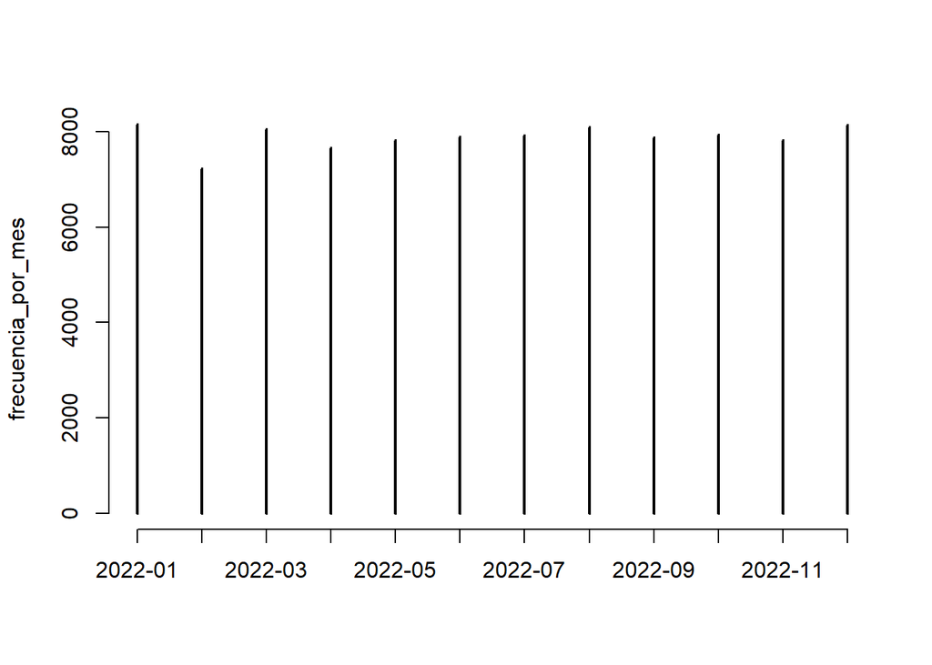

```r
# Realizar análisis de las compras en función de los componentes temporales
# Por ejemplo, calcular la suma de las compras por año
compras_por_anio <- aggregate(total_compra ~ anio, data = datos, sum)

# Calcular la frecuencia de compras por día, semana o mes
frecuencia_por_mes <- table(format(datos$fecha_compra, "%Y-%m"))
frecuencia_por_semana <- table(format(datos$fecha_compra, "%Y-%U"))
frecuencia_por_dia <- table(format(datos$fecha_compra, "%Y-%m-%d"))
frecuencia_por_dia_semana <- table(format(datos$dia_semana))


# Visualizar los resultados
plot(frecuencia_por_mes)
```

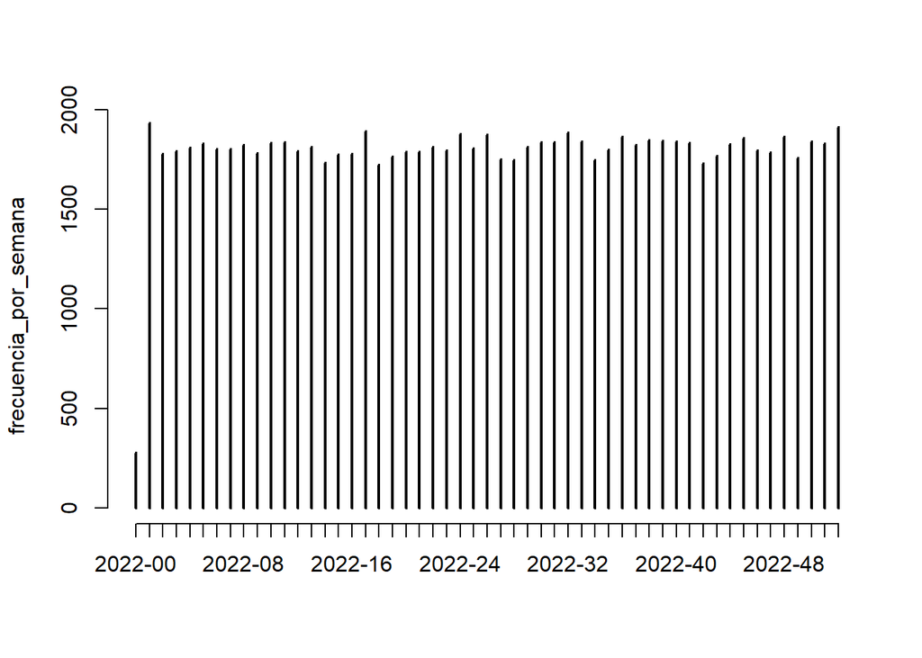

```r
plot(frecuencia_por_semana)
```

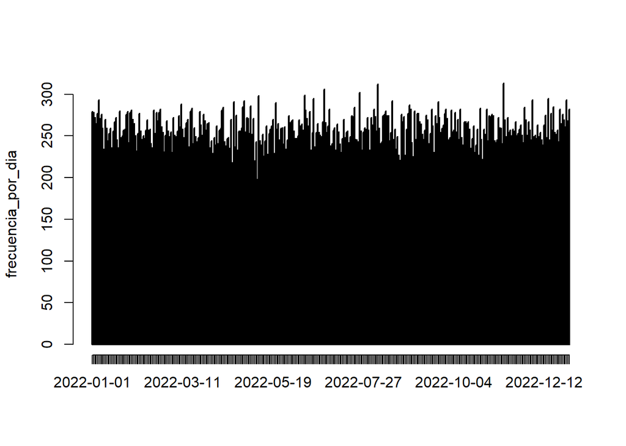

```r
plot(frecuencia_por_dia)
```

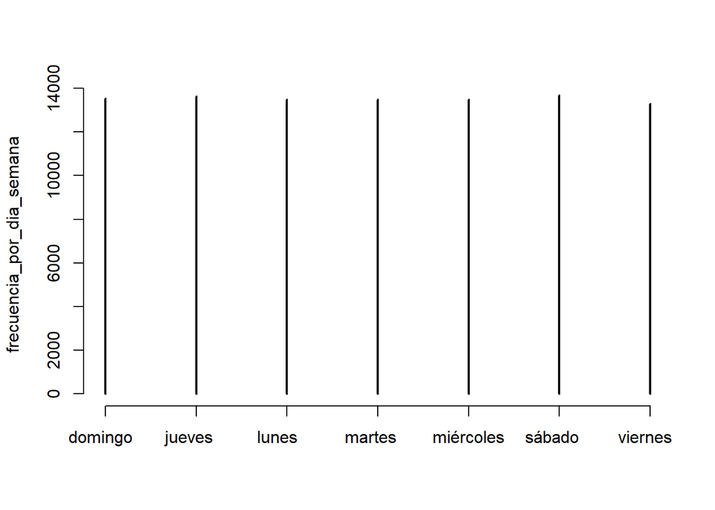

```r
plot(frecuencia_por_dia_semana)
```

De lo anterior se concluye que las compras tienen un comportamiento univorme a lo largo del año.

Podemos visualizar cómo varían las compras a lo largo del tiempo con un gráfico de líneas

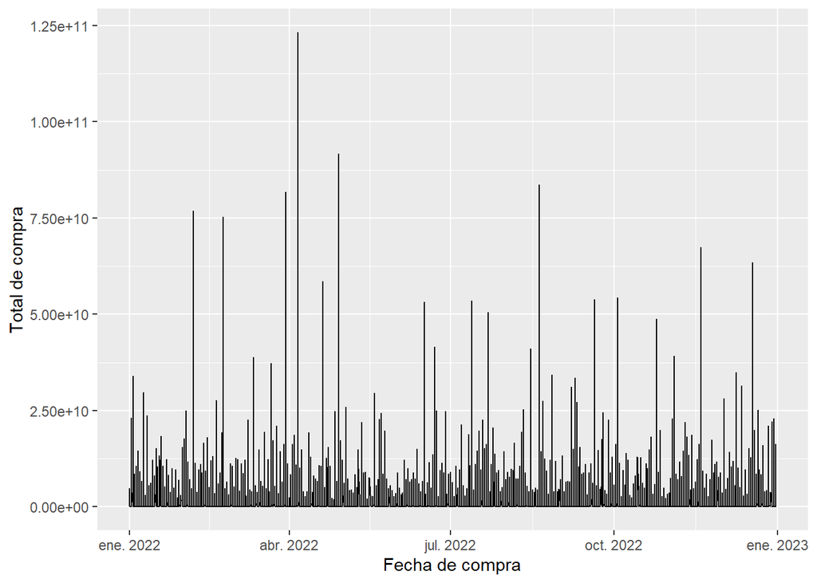

```r
csv_ord$fecha_compra = as.Date(csv_ord$fecha_compra) # Primero, nos aseguramos de que la columna fecha_compra esté en formato de fecha

# Utilizando ggplot2
ggplot(csv_ord, aes(x = fecha_compra, y = total_compra)) +
  geom_line() +
  labs(x = "Fecha de compra", y = "Total de compra")
```

```r
chosen_col_7 <- c("fecha_compra", "total_compra")
subset_7 = unique(csv_ord[, chosen_col_7])

# Paso 1: Agrupar los datos por "fecha_compra"
grupos = subset_7 %>% group_by(fecha_compra) %>%
# Paso 2: Contar la cantidad de "total_compra" distintos
  summarize(num_total_compra = n_distinct(total_compra))

# Paso 3: Filtrar aquellos casos con más de un "tipo_tienda"
MuchasVentas = grupos %>% filter(num_total_compra > 275)
PocasVentas = grupos %>% filter(num_total_compra < 221)

MuchasVentas
```

```
## # A tibble: 9 × 2
##   fecha_compra num_total_compra
##   <date>                  <int>
## 1 2022-01-06                279
## 2 2022-05-08                279
## 3 2022-05-21                280
## 4 2022-06-19                281
## 5 2022-07-24                277
## 6 2022-08-07                289
## 7 2022-11-11                288
## 8 2022-12-03                278
## 9 2022-12-15                280
```

```r
PocasVentas
```

```
## # A tibble: 23 × 2
##    fecha_compra num_total_compra
##    <date>                  <int>
##  1 2022-02-04                217
##  2 2022-02-25                215
##  3 2022-03-03                219
##  4 2022-03-16                220
##  5 2022-04-01                218
##  6 2022-04-03                217
##  7 2022-04-07                217
##  8 2022-04-16                220
##  9 2022-04-18                212
## 10 2022-04-20                220
## # ℹ 13 more rows
```